# Practical Machine Learning Course Project Report

sidjain89

March 13, 2016

### Section 0: Loading data

- Using the code below, download the files into a local folder and read into data frames.
- Since this method uses an internet connection to download and load files, its better to mannually download once and read files.

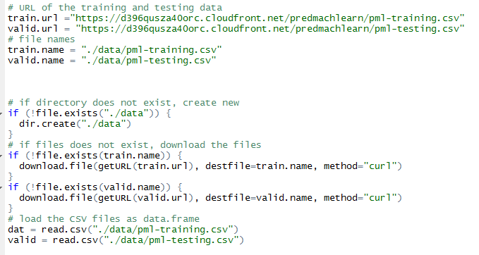

### Section 1: Cleaning the data

- Using the code `summary(dat)` it was observed that some variables had a lot of (19000+) missing values
- Apart from them, some variables such as TimeStamps, User Names, IDs will be removed as they are not required for modelling.
- Encapsulated the pruning code into a function so that it can be reused for the validation set
- After pruning, we are left with 49 variables (48 predictors and 1 target variable)

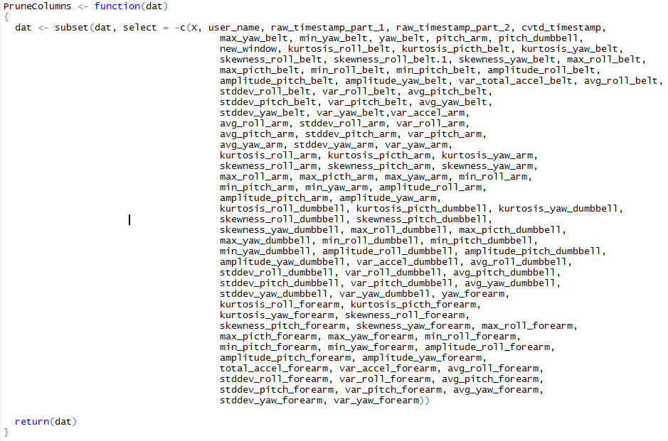

### Section 2: Preprocessing of Data

- Since all of the predictor variables are continuous, will use the Z-Transformation to remove the bias.
- The method below will replace each numeric value for a column by a Z-Score.
- On plotting these Z-Scores we will get a well shaped bell curve as all the data is now being normalized
- Partition the data into train and test sets in 70:30 ratio.

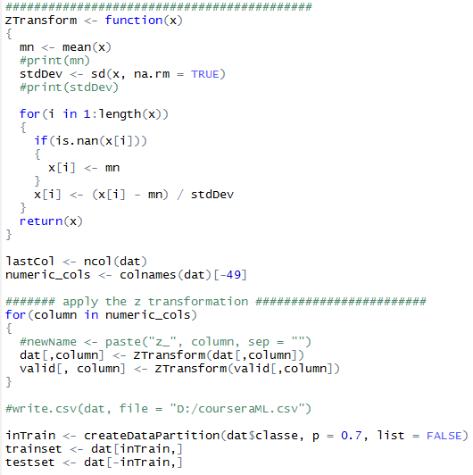

### Section 3: Build the Model and apply to validation set

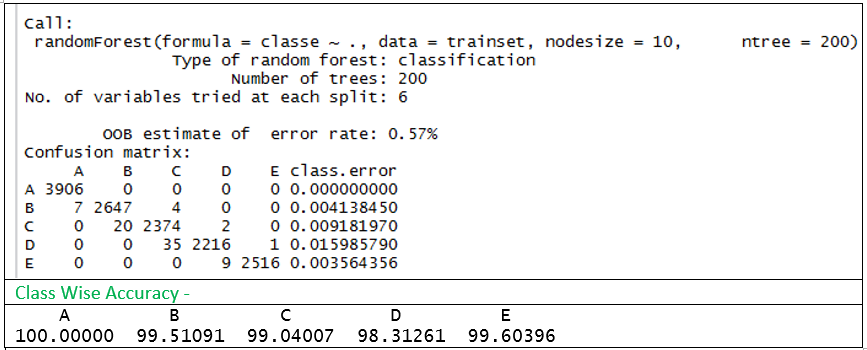

**I will now cross verify these results over the testing set (30% of the data obtained from split)**

- In the test set the accuracy is 99.63% which is similar to the training set. Thus we are good to go with this model.
- Accuracy levels for individual classes too mimic the training set levels and are well above 99%

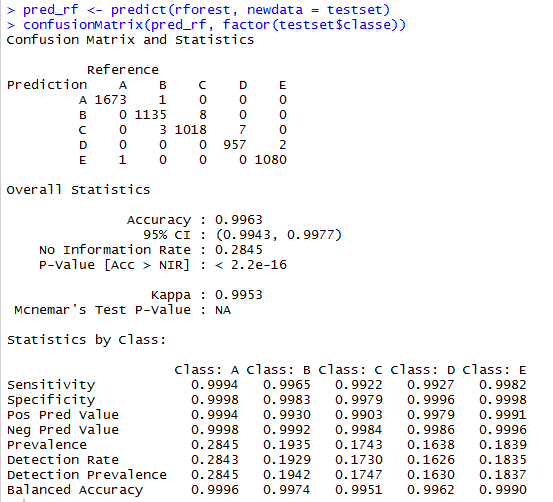

**The graph below summerizes the relative imporatnce of variables obtained by `varImpPlot(rforest)`**

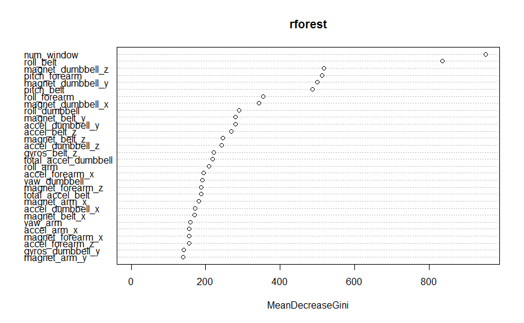

**Now the model can be applied to the validation set - `pml-testing.csv`**

```r
pred_valid <- predict(rforest, newdata = valid)pred_valid
```

[output not shown]

**NOTE:**

- Since we have to limit use of images, I could not put the plots of numeric variables to make the case of using Z-Scores
- I did modelling without using Z-Scores, the result was 0.8% OOB error rate in training and around 99.3x% accuracy in test
- Thus using the Z-Scores improved the model performance